# Project Python Foundations: FoodHub Data Analysis

**Marks: 60**

### Context

The number of restaurants in New York is increasing day by day. Lots of students and busy professionals rely on those restaurants due to their hectic lifestyles. Online food delivery service is a great option for them. It provides them with good food from their favorite restaurants. A food aggregator company FoodHub offers access to multiple restaurants through a single smartphone app.

The app allows the restaurants to receive a direct online order from a customer. The app assigns a delivery person from the company to pick up the order after it is confirmed by the restaurant. The delivery person then uses the map to reach the restaurant and waits for the food package. Once the food package is handed over to the delivery person, he/she confirms the pick-up in the app and travels to the customer's location to deliver the food. The delivery person confirms the drop-off in the app after delivering the food package to the customer. The customer can rate the order in the app. The food aggregator earns money by collecting a fixed margin of the delivery order from the restaurants.

### Objective

The food aggregator company has stored the data of the different orders made by the registered customers in their online portal. They want to analyze the data to get a fair idea about the demand of different restaurants which will help them in enhancing their customer experience. Suppose you are hired as a Data Scientist in this company and the Data Science team has shared some of the key questions that need to be answered. Perform the data analysis to find answers to these questions that will help the company to improve the business.

### Data Description

The data contains the different data related to a food order. The detailed data dictionary is given below.

### Data Dictionary

- order_id: Unique ID of the order
- customer_id: ID of the customer who ordered the food
- restaurant_name: Name of the restaurant
- cuisine_type: Cuisine ordered by the customer
- cost: Cost of the order
- day_of_the_week: Indicates whether the order is placed on a weekday or weekend (The weekday is from Monday to Friday and the weekend is Saturday and Sunday)
- rating: Rating given by the customer out of 5
- food_preparation_time: Time (in minutes) taken by the restaurant to prepare the food. This is calculated by taking the difference between the timestamps of the restaurant's order confirmation and the delivery person's pick-up confirmation.
- delivery_time: Time (in minutes) taken by the delivery person to deliver the food package. This is calculated by taking the difference between the timestamps of the delivery person's pick-up confirmation and drop-off information

### Let us start by importing the required libraries

```python
# import libraries for data manipulation
import numpy as np
import pandas as pd

# import libraries for data visualization
import matplotlib.pyplot as plt
import seaborn as sns
```

### Understanding the structure of the data

```python
# uncomment and run the following lines for Google Colab
from google.colab import drive
drive.mount('/content/drive')
```

```python
# read the data
df = pd.read_csv('/content/drive/MyDrive/Colab Notebooks/Python Data/foodhub_order.csv')
# returns the first 5 rows
df.head()
```

|  | order_id | customer_id | restaurant_name | cuisine_type | cost_of_the_order | day_of_the_week | rating | food_preparation_time | delivery_time |
| --- | --- | --- | --- | --- | --- | --- | --- | --- | --- |
| 0 | 1477147 | 337525 | Hangawi | Korean | 30.75 | Weekend | Not given | 25 | 20 |
| 1 | 1477685 | 358141 | Blue Ribbon Sushi Izakaya | Japanese | 12.08 | Weekend | Not given | 25 | 23 |
| 2 | 1477070 | 66393 | Cafe Habana | Mexican | 12.23 | Weekday | 5 | 23 | 28 |
| 3 | 1477334 | 106968 | Blue Ribbon Fried Chicken | American | 29.20 | Weekend | 3 | 25 | 15 |
| 4 | 1478249 | 76942 | Dirty Bird to Go | American | 11.59 | Weekday | 4 | 25 | 24 |

#### Observations:

The DataFrame has 9 columns as mentioned in the Data Dictionary. Data in each row corresponds to the order placed by a customer.

- order_id, customer_id, cost_of_the_order, food_preparation_time and delivery_time are numerical
- restaurant_name, cuisine_type, day_of_the_week, and rating are categorical
- In the rating column, we can see that there are some "not given" values that will likely have to be addressed/cleaned in order to analyze data appropriately.
- "day_of_the_week" is a little misleading, where the data appears to only be broken into weekday and weekend, instead of identifying each individual day of the week.
- It may be advantageous to combine food_preparation_time and delivery_time into another column in order to get an idea of the 'total time' it takes for a customer to place the order and have the food arrive.
- restaurant_name and cuisine_type appear to be self explanatory. It appears to be the restaurant name and the respective type of cuisine associated with the food order.
- Considering the data is based on New York, cost_of_the_order is likely in dollars.
- Customer_id may be unique to each person or generated per order. Will be good to determine this.
- Although it is not stated, the order_id's are likely able to be ordered in a time series of sorts. The problem is we do not have a general timeframe or code decipher for the id (does not appear to be Julian). It would be good to ask the data provider this question to understand the trends over times or seasons.

### **Question 1:** How many rows and columns are present in the data? [0.5 mark]

```python
#Reviewed the 'shape' of the data to understand the number of rows and columns
print("There are",df.shape[0], "rows,", "and there are",df.shape[1],"columns")
```

```
There are 1898 rows, and there are 9 columns
```

#### Observations:

- There are a total of 1898 rows, and there are 9 columns in the data set/dataframe.

### **Question 2:** What are the datatypes of the different columns in the dataset? (The info() function can be used) [0.5 mark]

```python
# Use info() to print a concise summary of the DataFrame
df.info()
```

```
<class 'pandas.core.frame.DataFrame'>
RangeIndex: 1898 entries, 0 to 1897
Data columns (total 9 columns):
 #   Column                 Non-Null Count  Dtype
---  ------                 --------------  -----
 0   order_id               1898 non-null   int64
 1   customer_id            1898 non-null   int64
 2   restaurant_name        1898 non-null   object
 3   cuisine_type           1898 non-null   object
 4   cost_of_the_order      1898 non-null   float64
 5   day_of_the_week        1898 non-null   object
 6   rating                 1898 non-null   object
 7   food_preparation_time  1898 non-null   int64
 8   delivery_time          1898 non-null   int64
dtypes: float64(1), int64(4), object(4)
memory usage: 133.6+ KB
```

#### Observations:

- There are no 'null' data entries when we compare the count to the total number of rows.

Dtypes are as followed:

- int64 (integer): order_id, customer_id, food_preparation_time, and delivery time
- float64 (float): cost_of_the_order
- object: restaurant_name, cuisine_type, day_of_the_week, and rating.

As expected, considering there is are non-numerical values ("not given") in the rating column, we have returned a data type which is an object.

### **Question 3:** Are there any missing values in the data? If yes, treat them using an appropriate method. [1 mark]

```python
#Observing the number of data points which may be missing by looking at "null values, this can also be evaluted through ,.info()
print(df.isnull().sum())
```

```
order_id                 0
customer_id              0
restaurant_name          0
cuisine_type             0
cost_of_the_order        0
day_of_the_week          0
rating                   0
food_preparation_time    0
delivery_time            0
dtype: int64
```

```python
#by using the .unique function, we are able to see how many 'not given" there are
print(df['rating'].unique())
print("\n")
#counting the number of each ratings in the data (or lack there of)
df['rating'].apply(str).value_counts()
```

```
['Not given' '5' '3' '4']
```

```
Not given    736
5            588
4            386
3            188
Name: rating, dtype: int64
```

```python
# It would not be wise to remove that much data from the entire data set, as most of the columns do appear to have useful data.
# We are making a copy of the dataframe
dfrm=df.copy()
#we are 'removing' all the 'not given'(s) in the new dataframe
dfrm.drop(dfrm[dfrm['rating'] == 'Not given'].index, inplace=True)
#reseting the index after dropping the 'not given's
dfrm=dfrm.reset_index()
#changeng the data type of rating to integers for numerical data analysis
dfrm['rating']=dfrm['rating'].astype(int)
#verifying the result
print(dfrm['rating'].unique())
```

```
[5 3 4]
```

#### Observations:

- Although there is no technical missing data in the form of NaN/null points. "not given" in the rating column will inevitably prevent us from analyzing the data set to its full potential. Particularly if we wanted to perform statistical analysis numerically, or moreso, objectively.
- 'not given' was presented 736 times out of 1898 ratings, which is approximately 40% of the data. This is a large chunk of the data, so it would not be wise to "drop" each of these rows in the original set of data.
- For now, we will create a separate dataframe called "dfrm" and analyze this data separately
- In addition, we will convert the object into an integer (int), so we can analyze the rating data numerically/objectively, e.g. determining the mean rating for a given restaurant, etc.

### **Question 4:** Check the statistical summary of the data. What is the minimum, average, and maximum time it takes for food to be prepared once an order is placed? [2 marks]

```python
#Statistical summaries can be checked using the .describe() function:

print(df['food_preparation_time'].describe())
```

```
count    1898.000000
mean       27.371970
std         4.632481
min        20.000000
25%        23.000000
50%        27.000000
75%        31.000000
max        35.000000
Name: food_preparation_time, dtype: float64
```

#### Observations:

- The minimum amount of time for an order to be prepared is 20.00 minutes
- The average is 27.37 minutes (rounded to the hundreths place)
- The maximum time is 35.00 minutes

The mean and median are very similar. In addition the Quartiles have equivelent separation i.e. Q2-Q1 & Q3-Q2, which means the data is likely normally distributed (like a bell curve).

In addition, although we have yet to look at plots. It does not appear that we are dealing with many/if any extreme values for this variable (such as prep time takes 2 mins or 120 mins).

### **Question 5:** How many orders are not rated? [1 mark]

```python
#again, counting the number of 'not given' values
print("The total number of each rating is shown below with 'Not given' ratings on orders equal to 736\n",df['rating'].value_counts())
#creating a space in the data display
print("\n")
#converting the rating values to a percentage of the total.
print("This can also be shown as a percentage (%) of the total\n", df['rating'].value_counts('Not given')*100)
```

```
The total number of each rating is shown below with 'Not given' ratings on orders equal to 736
 Not given    736
5            588
4            386
3            188
Name: rating, dtype: int64


This can also be shown as a percentage (%) of the total
 Not given    38.777661
5            30.979979
4            20.337197
3             9.905163
Name: rating, dtype: float64
```

#### Observations:

- 736 or ~38.78% were not rated.
- We will address this with the client to hopefully better understand the underlying reason, or come up with a plan to improve the demographic (if the client finds this important, which I suspect they do)
- Addressing one more topic, it is odd that all we see is 5,4,3 ratings. Were 1 & 2 already scrubbed before we received the data? I find it unlikely that the rating scale was 3-5.

### Exploratory Data Analysis (EDA)

### **Question 6:** Explore all the variables and provide observations on their distributions. (Generally, histograms, boxplots, countplots, etc. are used for univariate exploration.) [9 marks]

#### Order ID

The order_id column is highly individual, similar to an index. We may compare the order_id in the multivariate section, but for now, we will review the other variables.

```python
#determining how many unique values there are in order id column by using .nunique()
df['order_id'].nunique()
```

```
1898
```

#### Customer ID

One thing to note is that the count vs. the final or max customer ID number is significantly different. A couple questions to potentially ask the client is, does the customer ID number have more meaning then what it appears, such as, part of the number is a designation for location (in the city) or time?

However, what is more likely the case is that we recieved a snapshot of a single city, as we know our data is from New York. The total number of customer ID's could be spread across the US for example.

*Still* it is important to understand the distribution.

```python
#understand the basic distribution of the customer id column by using the .describe() function.
df['customer_id'].describe()
```

```
count      1898.000000
mean     171168.478398
std      113698.139743
min        1311.000000
25%       77787.750000
50%      128600.000000
75%      270525.000000
max      405334.000000
Name: customer_id, dtype: float64
```

What is interesting is the data is somewhat 'bimodal' with two peaks. One around 75,000, and a much smaller peak around 375,000.

This could very well be an indicator of a surge due to a promotional offer. For instance, perhaps there was an offering when the app first came out. Then, some time later, another promotional offer of a smaller proportional.

There is a big drop in what me may be able to consider 'new customers', and this may very well be due to a multitude of reasons. However, a potential talking point with the client. Note, alternatively, there could be a number of customer's using the app often, and perhaps there is some saturation.

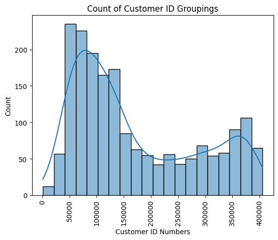

```python
# updating the basic elements of the graph/plot display to improve presentability and readability.
plt.title('Count of Customer ID Groupings')
plt.xlabel('Customer ID Numbers')
plt.ylabel('Count')
#rotating the x-axis ticks/increments so the there is separation between the ticks and it doesnt 'blend 'together
plt.xticks(rotation=90)
#creating a histogram for the customer id column, using more 'bins' to help avoid blending of the data, where we may miss a more detailed element.
sns.histplot(data=df,x='customer_id', bins=20, kde=True);
```

There are 1200 unique IDs! Which means a fair number of customers have likely only used the app once.

```python
# Evaluating the number of unique values, or more simply, the number of individual customers and how many orders they have placed.
print(df['customer_id'].nunique())
print(df['customer_id'].value_counts().unique())
```

```
1200
[13 10  9  8  7  6  5  4  3  2  1]
```

Indeed, our assumption is correct. There are what appears to be a people using the app only once. The lack of repeatability is concerning.

```python
#organized and sorted the data by # of orders placed (first column) and the amount of customers who placed that number of orders (column 2). For instance, 267 customers have place two orders each (used the app on two separate occassions)
customer_count = df['customer_id'].value_counts()
customer_count.value_counts().sort_index()
```

```
1     784
2     267
3      83
4      33
5      19
6       6
7       4
8       1
9       1
10      1
13      1
Name: customer_id, dtype: int64
```

#### Restaurant Name

By taking a look at the Top 10 Restaurants by quantity of individual orders, we can see that the "Shake Shack" has quite a lead, and the following 3, The Meatball Shop, BR Sushi, and BR Fried Chicken are fairly ahead of the competition. It will/would be good to understand what these restaurants are doing differently (Marketing, food quality, promotions, etc.)

```
Shake Shack                      219
The Meatball Shop                132
Blue Ribbon Sushi                119
Blue Ribbon Fried Chicken         96
Parm                              68
RedFarm Broadway                  59
RedFarm Hudson                    55
TAO                               49
Han Dynasty                       46
Blue Ribbon Sushi Bar & Grill     44
Name: restaurant_name, dtype: int64
```

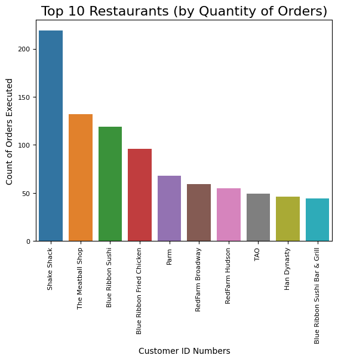

```python
# updating the basic elements of the graph/plot display to improve presentability and readability.
plt.title('Top 10 Restaurants (by Quantity of Orders)', fontsize=16)
plt.xticks(fontsize=8)
plt.yticks(fontsize=8)
plt.xticks(rotation=90)
#ordered and found the top ten restaurants with the most orders
order = df['restaurant_name'].value_counts().nlargest(10).index
# created a small data set to review the totals for each restaurant in the top 10
print(df['restaurant_name'].value_counts().nlargest(10))
#charted the results in a count plot
sns.countplot(data = df, x = 'restaurant_name', order=order);
# additional elements to improve readability
plt.xlabel('Customer ID Numbers', fontsize=10)
plt.ylabel('Count of Orders Executed', fontsize=10);
```

##### Day of the Week

The order count on the weekend is significantly higher than during the weekday even though there are 3 fewer days. This is certainly an important finding from a sales and resource focus perspective.

```
Weekend    1351
Weekday     547
Name: day_of_the_week, dtype: int64
```

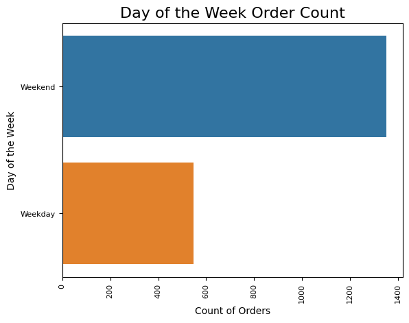

```python
# updating the basic elements of the graph/plot display to improve presentability and readability.
plt.title('Day of the Week Order Count', fontsize=16)
plt.xticks(fontsize=8)
plt.yticks(fontsize=8)
plt.xticks(rotation=90)
#creating the countplot
sns.countplot(data = df, y= 'day_of_the_week')
plt.xlabel('Count of Orders', fontsize=10)
plt.ylabel('Day of the Week', fontsize=10)
#providing the number of orders made on the weekend vs. the weekday
print(df['day_of_the_week'].value_counts());
```

#### Food Preparation, Delivery Time, & Customer Wait Time

By comparing the food preparation and delivery time. We can see that the average time (mean) is relatively close between the two variables. With food preparation time, average a couple minutes longer. As we put these two variables together in "customer_wait", we can see that time it takes from placing an order to the customer receiving it. This also shows us that there is a relatively wide range of time it takes for the customer to place the order and receive it.

What may be interesting data is if we had time of day. Does rush hour play a role? Such as, increase the delivery time? Do more orders come in during regular eating periods in the day and cause the preparation time to go up?

Also, do some restuarants have a larger area for which they deliver too?

```
count    1898.000000
mean       27.371970
std         4.632481
min        20.000000
25%        23.000000
50%        27.000000
75%        31.000000
max        35.000000
Name: food_preparation_time, dtype: float64
```

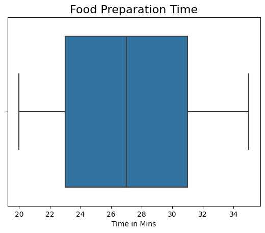

```python
# updating the basic elements of the graph/plot display to improve presentability and readability.
plt.title('Food Preparation Time', fontsize=16)
# creating a boxplot of food preparation time
sns.boxplot(data=df,x="food_preparation_time")
plt.xlabel('Time in Mins', fontsize=10)
# using the describe function to provide a numerical distribution, average, median, etc.
print(df['food_preparation_time'].describe());
```

```
count    1898.000000
mean       24.161749
std         4.972637
min        15.000000
25%        20.000000
50%        25.000000
75%        28.000000
max        33.000000
Name: delivery_time, dtype: float64
```

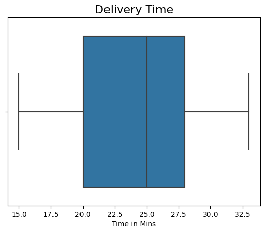

```python
#similar to preparation time, observing the delivery time in the same way
plt.title('Delivery Time', fontsize=16)
sns.boxplot(data=df,x="delivery_time")
plt.xlabel('Time in Mins', fontsize=10)
print(df['delivery_time'].describe());
```

```
count    1898.000000
mean       51.533720
std         6.833603
min        35.000000
25%        47.000000
50%        52.000000
75%        56.000000
max        68.000000
Name: customer_wait, dtype: float64
```

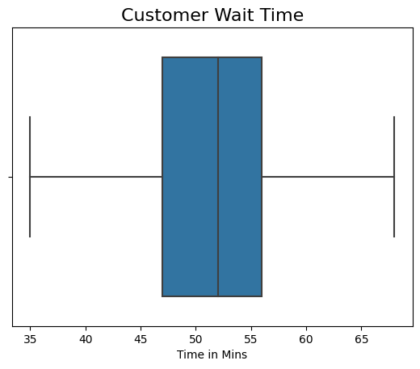

```python
#combined food prep and delivery time into one column (summation of the two) and put the column in the original data frame.
df['customer_wait']=df['food_preparation_time']+df['delivery_time']
# created a boxplot similr to food prep and delivery time to compare all the visualizations and data.
plt.title('Customer Wait Time', fontsize=16)
sns.boxplot(data=df,x="customer_wait")
plt.xlabel('Time in Mins', fontsize=10)
print(df['customer_wait'].describe());
```

#### Cuisine Type

American cuisine has largest amount of orders (584). While Japanese is not fair behind (470). After a jump, Italian (298) and Chinese (215) come in 3rd and 4th. These 4 cuisines make up 82.56% of the total orders!

```
American          584
Japanese          470
Italian           298
Chinese           215
Mexican            77
Indian             73
Middle Eastern     49
Mediterranean      46
Thai               19
French             18
Southern           17
Korean             13
Spanish            12
Vietnamese          7
Name: cuisine_type, dtype: int64
```

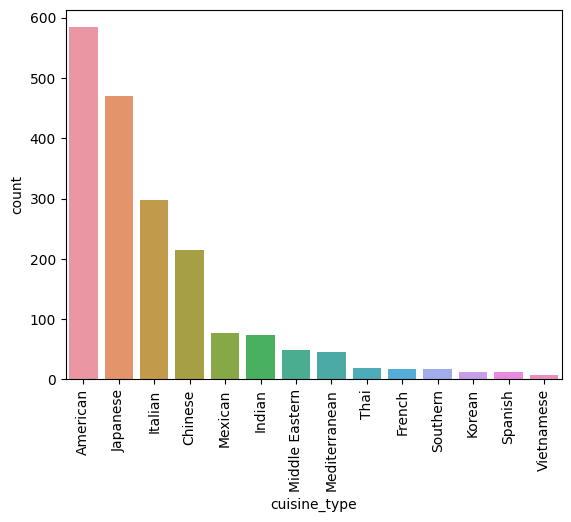

```python
#printed cuisine data and sorted the values (largest to smallest)
order_cuisine_type=df['cuisine_type'].value_counts().sort_values(ascending=False)
print(order_cuisine_type)
plt.xticks(rotation=90)
# used the sorted data to create a graph in the same order.
sns.countplot(data=df,x="cuisine_type",order=order_cuisine_type.index);
```

```python
#determining what % composition the top 4 cuisines are compared to the total
order_cuisine_type.nlargest(4).sum()/order_cuisine_type.sum()*100
```

```
82.56059009483667
```

#### Cost of the Order

The cost of the appears to have a right skewness with half of the orders costing less than $14.14, but the average being higher at $16.49. In addition, 50% of the data falls between about $12-$22. The highest costing order being approximately $35 and the lowest costing around $4.50.

```
count    1898.000000
mean       16.498851
std         7.483812
min         4.470000
25%        12.080000
50%        14.140000
75%        22.297500
max        35.410000
Name: cost_of_the_order, dtype: float64
```

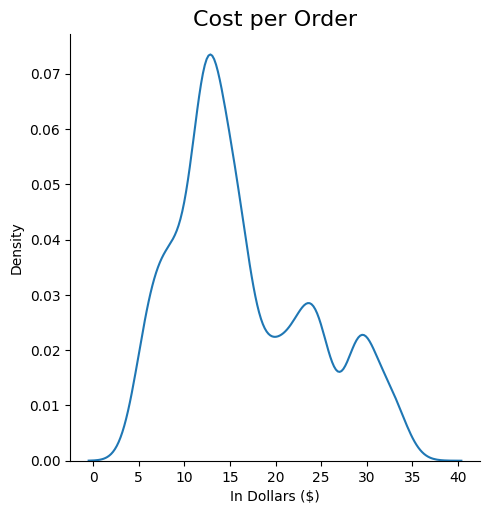

```python
#observing the kernal density (kde) of cost per order
sns.displot(data=df,x="cost_of_the_order",kind='kde');
# updating the basic elements of the graph/plot display to improve presentability and readability.
plt.title('Cost per Order', fontsize=16)
plt.xlabel('In Dollars ($)', fontsize=10)
print(df['cost_of_the_order'].describe());
```

#### Customer Rating

The majority of orders that were rated were rated a 5, and nearly 84% were rated a 4 or above.

```
5    588
4    386
3    188
Name: rating, dtype: int64
```

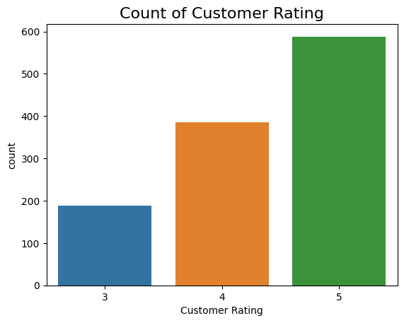

```python
# updating the basic elements of the graph/plot display to improve presentability and readability.
plt.title('Count of Customer Rating', fontsize=16)
#created a countplot to review the proportion of orders with each rating (3-5)
sns.countplot(data=dfrm,x="rating")
plt.xlabel('Customer Rating', fontsize=10)
print(dfrm['rating'].value_counts());
```

```python
#understanding the percentage of ratings greather than 3, i.e. 4 & 5
print((dfrm['rating']>3).mean()*100,"%")
```

```
83.8209982788296 %
```

### **Question 7**: Which are the top 5 restaurants in terms of the number of orders received? [1 mark]

```python
#counting the number of orders for the top 5 restaurants
df['restaurant_name'].value_counts().nlargest(5)
```

```
Shake Shack                  219
The Meatball Shop            132
Blue Ribbon Sushi            119
Blue Ribbon Fried Chicken     96
Parm                          68
Name: restaurant_name, dtype: int64
```

#### Observations:

The most popular restaurants in order are: Shake Shack, The Meatball Shop, Blue Ribbon Sushi, Blue Ribbon Fried Chicken, and Parm. Shake Shack is by far the most popular with 219 orders, or a little over 11% of the total orders on Foodhub (New York).

### **Question 8**: Which is the most popular cuisine on weekends? [1 mark]

```python
#grouping and counting the number of orders for each cuisine by day of the week (weekday or weekend)
df.groupby(['day_of_the_week'])['cuisine_type'].value_counts()
```

```
day_of_the_week  cuisine_type
Weekday          American          169
                 Japanese          135
                 Italian            91
                 Chinese            52
                 Indian             24
                 Mexican            24
                 Middle Eastern     17
                 Mediterranean      14
                 Southern            6
                 French              5
                 Thai                4
                 Vietnamese          3
                 Korean              2
                 Spanish             1
Weekend          American          415
                 Japanese          335
                 Italian           207
                 Chinese           163
                 Mexican            53
                 Indian             49
                 Mediterranean      32
                 Middle Eastern     32
                 Thai               15
                 French             13
                 Korean             11
                 Southern           11
                 Spanish            11
                 Vietnamese          4
Name: cuisine_type, dtype: int64
```

#### Observations:

The Most popular cuisine on the Weekend is American cuisine (415 orders).

### **Question 9**: What percentage of the orders cost more than 20 dollars? [2 marks]

```python
# took all the orders in the data set that are greater than $20 and coverted the data to a %.
print((df['cost_of_the_order']>20).mean()*100,"%")
```

```
29.24130663856691 %
```

#### Observations:

The percentage of orders that cost more than $20 is 29.24 % (rounded)

### **Question 10**: What is the mean order delivery time? [1 mark]

```python
#determining the mean for the delivery data using the .mean() function.
df['delivery_time'].mean()
```

```
24.161749209694417
```

#### Observations:

The mean delivery time is 24.16 minutes.

### **Question 11:** The company has decided to give 20% discount vouchers to the top 3 most frequent customers. Find the IDs of these customers and the number of orders they placed. [1 mark]

```python
# counting the customer ids (individual customers) and selecting the top 3.
df['customer_id'].value_counts().nlargest(3)
```

```
52832    13
47440    10
83287     9
Name: customer_id, dtype: int64
```

#### Observations:

The 3 most frequent customers are:

1. 52832 with 13 orders
2. 47440 with 10 orders
3. 83287 with 9 orders

### **Question 12**: Perform a multivariate analysis to explore relationships between the important variables in the dataset. (It is a good idea to explore relations between numerical variables as well as relations between numerical and categorical variables) [10 marks]

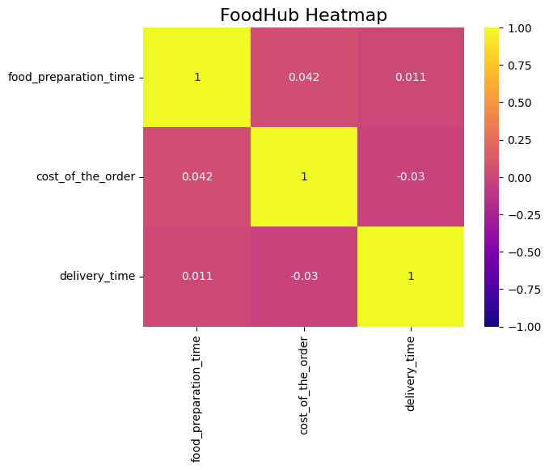

```python
# updating the basic elements of the graph/plot display to improve presentability and readability.
plt.title('FoodHub Heatmap', fontsize=16)
# selecting the (numerical) variables to be used in the heat map
df_heatmap=df[['food_preparation_time','cost_of_the_order','delivery_time']]
# turning the selections into a correlation with heatmap.
# included #'a in each cell with annot, changed the color (plasmas easy to see differences) adjusted the correlation strength range to 1 - -1
sns.heatmap(df_heatmap.corr(), annot=True, cmap='plasma', vmin=-1, vmax=1);
```

There are no apparent correlations between numerical values from the dataset.

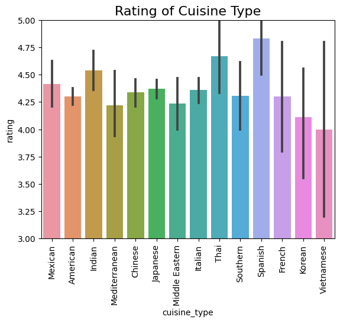

```python
# updating the basic elements of the graph/plot display to improve presentability and readability.
plt.title('Rating of Cuisine Type', fontsize=16)
plt.xticks(rotation=90)
# adjusted the y-axis range to provide a better visualization of differences in rating.
plt.ylim(3,5)
# created a simple barplot of cusine type vs. rating.
sns.barplot(data = dfrm, x='cuisine_type', y='rating');
```

The rating range was adjusted in order to better visualize the similarities and differences among cuisine types.

The highest (average) rated cuisine types are Spanish and Thai, while the lowest are Korean and Vietnamese.

Understanding what sets these highly rated cuisines apart may be a worthwhile venture to discover what attributes a customer may be looking for to rate the restaurants higher.

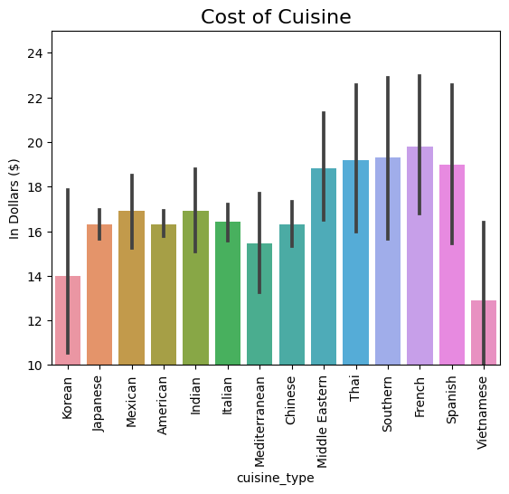

```python
# updating the basic elements of the graph/plot display to improve presentability and readability.
plt.title('Cost of Cuisine', fontsize=16)
plt.xticks(rotation=90)
# adjusted the range for better visibility
plt.ylim(10,25)
#created a simple barplot comparing cuisine and cost of the order
sns.barplot(data = df, x='cuisine_type', y='cost_of_the_order')
plt.ylabel('In Dollars ($)');
```

There appears to be 3 general tiers of average cost per cuisine.

Highest Cost Cuisine: Middle Eastern, Thai, Southern, French, and Spanish Moderate Cost Cuisine: Japanese, Mexican, American, Indian, Italian, Mediterranean, and Chinese Low Cost Cuisine: Korean and Vietnamese

Interestingly, the cheapest cuisine (Vietnamese) is also the lowest rated.

```
cuisine_type  day_of_the_week
American      Weekend            415
Japanese      Weekend            335
Italian       Weekend            207
American      Weekday            169
Chinese       Weekend            163
Japanese      Weekday            135
Italian       Weekday             91
Mexican       Weekend             53
Chinese       Weekday             52
Indian        Weekend             49
Name: day_of_the_week, dtype: int64
```

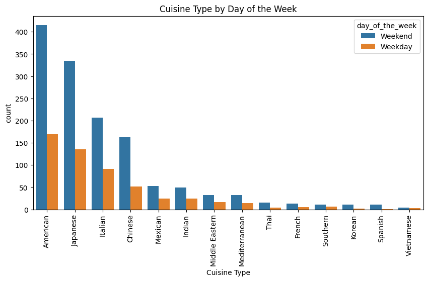

```python
# updating the basic elements of the graph/plot display to improve presentability and readability.
plt.figure(figsize=(10, 5))
plt.title('Cuisine Type by Day of the Week')
# wanted to order the data by number of orders for cuisine type in the graph.
order = df.groupby('cuisine_type').size().sort_values().index[::-1]
# counted the values of cuisine by largest to smallest, indiscriminately of day of the week, in order to see the order overall.
print((df.groupby(['cuisine_type'])['day_of_the_week']).value_counts().nlargest(10).sort_values(ascending=False))
# turned this data into a basic countplot, but separated the day of the week (using 'hue')
sns.countplot(data=df, x='cuisine_type', order=order, hue='day_of_the_week')
plt.xticks(rotation=90)
plt.xlabel('Cuisine Type');
```

The 'top 4' cuisines, American, Japanese, Italian, Chinese, have significantly more orders then the rest of cuisine.

Weekend orders are also consistently higher by a high margin.

Note, Vietnamese food, although the illustrated as lowest cost and worst rated, has very few orders/ratings. Therefore, there may not be enough data generated to determine how much customers enjoy the cuisine with such few data points.

```
                 restaurant_name  cost_of_the_order
0                    Shake Shack            3579.53
1              The Meatball Shop            2145.21
2              Blue Ribbon Sushi            1903.95
3      Blue Ribbon Fried Chicken            1662.29
4                           Parm            1112.76
5               RedFarm Broadway             965.13
6                 RedFarm Hudson             921.21
7                            TAO             834.50
8                    Han Dynasty             755.29
9  Blue Ribbon Sushi Bar & Grill             666.62
```

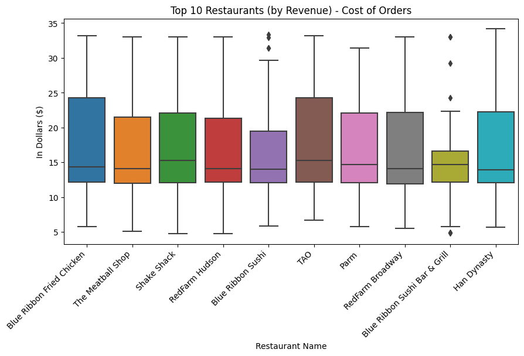

```python
# firstly, grouped and selected the 10 restaurants with the highest revenue of orders
revenue = df.groupby('restaurant_name')['cost_of_the_order'].sum().nlargest(10)

# rest the index and printed values
revenue = revenue.reset_index()
print(revenue)

# Created a boxplot of restaurant vs. cost of the order, made the plot a little bigger for readability and selected boundaries according to the revenue key (isin fuction used).
plt.figure(figsize=(10, 5))
plt.title('Top 10 Restaurants (by Revenue) - Cost of Orders')
sns.boxplot(data=df[df['restaurant_name'].isin(revenue['restaurant_name'])], x='restaurant_name', y='cost_of_the_order')
plt.xticks(rotation=45, ha='right')
plt.xlabel('Restaurant Name')
plt.ylabel('In Dollars ($)');
```

The median cost of the top 10 restaurants (by total revenue of orders) is fairly similar (between 13-16 dollars). While some have a wider range of order cost, 13-16/order seems to be an effective pricing range to ensure customer order volume.

Additionally, by looking at the top 10 restaurants by revenue, Shake Shack is against producing very good results compared to other establishments.

| day_of_the_week | count | mean | std | min | 25% | 50% | 75% | max |
| --- | --- | --- | --- | --- | --- | --- | --- | --- |
| Weekday | 547.0 | 16.311188 | 7.479521 | 4.75 | 12.08 | 14.07 | 22.285 | 35.41 |
| Weekend | 1351.0 | 16.574833 | 7.486979 | 4.47 | 12.08 | 14.41 | 22.285 | 33.37 |

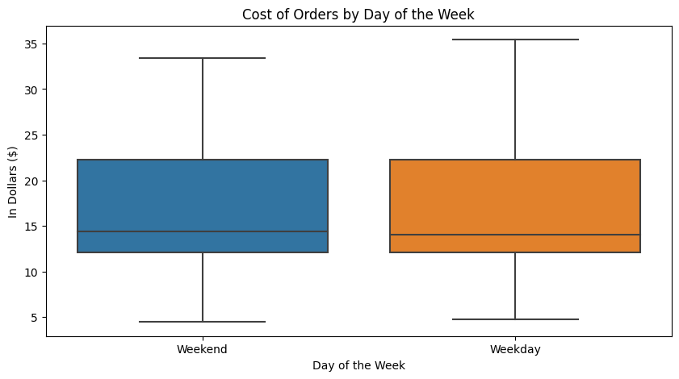

```python
# updating the basic elements of the graph/plot display to improve presentability and readability.
plt.figure(figsize=(10, 5))
plt.title('Cost of Orders by Day of the Week')

#created a boxplot of day of the week vs. cost of the order
sns.boxplot(data=df, x='day_of_the_week', y='cost_of_the_order')

plt.xlabel('Day of the Week')
plt.ylabel('In Dollars ($)');

#included a describe function to have a more detailed look at the data.
(df.groupby(df['day_of_the_week'])['cost_of_the_order']).describe()
```

There are no major order cost differences based on the time of the week (weekend or weekday)

```
The average customer wait time on the weekend is (in mins): 49.90673575129534
The average customer wait time on the weekday is (in mins): 55.552102376599635
```

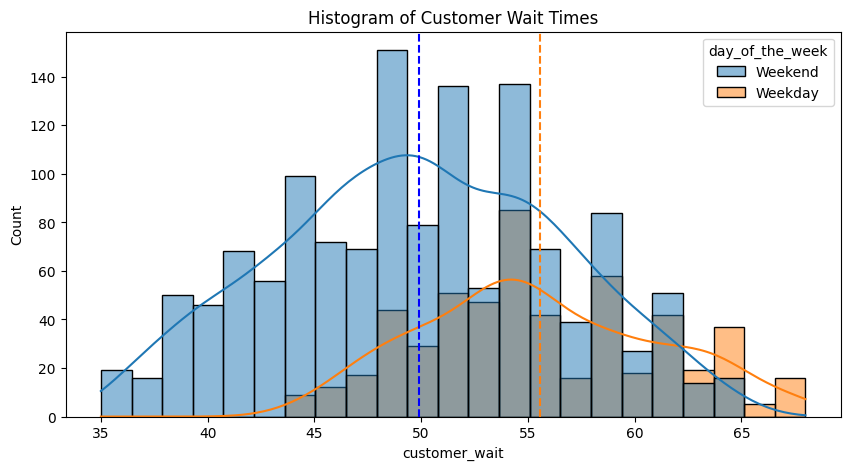

```python
#adjusted size of plot
plt.figure(figsize=(10, 5))

# grouped the data into Weekend and Weekday individually using the .loc function.
df_loc_weekend = df.loc[df['day_of_the_week'] == 'Weekend']
df_loc_weekday = df.loc[df['day_of_the_week'] == 'Weekday']

# Calculated the mean of 'customer_wait' time for the weekend and weekday. Then printed the values
df_weekend = df_loc_weekend['customer_wait'].mean()
df_weekday = df_loc_weekday['customer_wait'].mean()
print('The average customer wait time on the weekend is (in mins):', df_weekend)
print('The average customer wait time on the weekday is (in mins):',df_weekday)

# Created a histogram plot with a kde to display the density curve
sns.histplot(data=df, x='customer_wait', hue='day_of_the_week', kde=True)

# Added a vertical line for the mean of 'customer_wait' for the weekend and weekday. Changed the line style and color to match the bars
plt.axvline(x=df_weekend, color="b", linestyle='--')
plt.axvline(x=df_weekday, color="C1", linestyle='--')

# Set the title
plt.title('Histogram of Customer Wait Times');
```

Customers tend to have a longer wait on the weekdays vs. weekends. Perhaps due to traffic or staffing differences, etc.

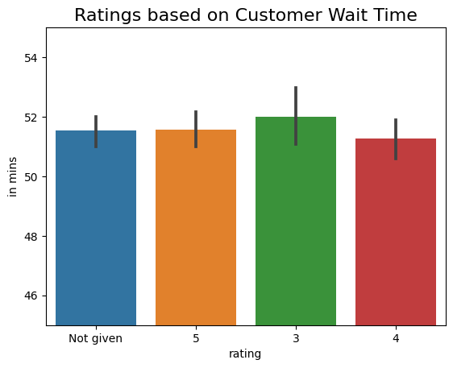

```python
# updating the basic elements of the graph/plot display to improve presentability and readability.
plt.title('Ratings based on Customer Wait Time', fontsize=16)
#adjusted limits for readibility
plt.ylim(45,55)
#created a simple barchart of rating vs. customer wait
sns.barplot(data = df, x = 'rating', y = 'customer_wait')
plt.ylabel('in mins');
```

Ratings do not appear to be correlated to customer wait time. Although the lower ratings (3) tend to be a little longer, it is within +/- 1 min compared to other ratings.

### **Question 13:** The company wants to provide a promotional offer in the advertisement of the restaurants. The condition to get the offer is that the restaurants must have a rating count of more than 50 and the average rating should be greater than 4. Find the restaurants fulfilling the criteria to get the promotional offer. [3 marks]

```python
#started with the dataframe with the 'not given'(s) removed.
#grouped the mean ratings and transformed them into the data set for each restaurant
dfrm['mean_rating'] = dfrm.groupby('restaurant_name')['rating'].transform('mean')
#grouped the count of the ratings by restaurant and transformed it back into the dataset
dfrm['count']=dfrm.groupby('restaurant_name')['rating'].transform('count')
#filtered the data by conditions >4 rating and >50 count of rating.
filtered_data = dfrm[(dfrm['mean_rating'] > 4) & (dfrm['count'] > 50)]
#displayed the restaurant's using .unique function.
filtered_data['restaurant_name'].unique()
```

```
array(['Blue Ribbon Fried Chicken', 'Shake Shack', 'Blue Ribbon Sushi',
       'The Meatball Shop'], dtype=object)
```

#### Observations:

The restaurants that meet the condition of both having more than 50 ratings and the average rating being greater than 4 are: 'Blue Ribbon Fried Chicken', 'Shake Shack', 'Blue Ribbon Sushi', and 'The Meatball Shop'.

### **Question 14:** The company charges the restaurant 25% on the orders having cost greater than 20 dollars and 15% on the orders having cost greater than 5 dollars. Find the net revenue generated by the company across all orders. [3 marks]

```python
# created a new column in the dataset of net revenue created by orders greater than $20 / multiplied the values by 25%
df['revenue_order_25%'] = 0

df.loc[df['cost_of_the_order'] > 20, 'revenue_order_25%'] = df['cost_of_the_order'] * 0.25

# created a new column in the dataset of net revenue created by orders less than or equal to $20 and greater than $5 / multiplied the values by 15%
df['revenue_order_15%'] = 0

df.loc[(df['cost_of_the_order'] > 5) & (df['cost_of_the_order'] <= 20), 'revenue_order_15%'] = df['cost_of_the_order'] * 0.15

# summated the individual revenues in order to understand which orders are more profitable overall.
revenue_25=df['revenue_order_25%'].sum()
revenue_15=df['revenue_order_15%'].sum()

# added the revenues together in order to determine the total
total_net_revenue = revenue_25 + revenue_15

print("The net revenue created by order's greater than $20 is: $", revenue_25)
print("The net revenue created by order's less than or equal $20 and greater than $5 is: $", revenue_15)
print("Total Net Revenue: $", total_net_revenue)
```

```
The net revenue created by order's greater than $20 is: $ 3688.7275
The net revenue created by order's less than or equal $20 and greater than $5 is: $ 2477.5755
Total Net Revenue: $ 6166.303
```

#### Observations:

The total net revenue generated by the company across all the orders is $6166.30.

There is more revenue generated by orders that are greater than $20.

### **Question 15:** The company wants to analyze the total time required to deliver the food. What percentage of orders take more than 60 minutes to get delivered from the time the order is placed? (The food has to be prepared and then delivered.) [2 marks]

```python
# determined customer wait time, which is a combination of prep time and delivery time and counted the number of orders greater than 60 mins.
print((df['customer_wait']>60).value_counts());
```

```
False    1698
True      200
Name: customer_wait, dtype: int64
```

```python
#determined percentage of total by taking the 'True' values and dividing by the total number of orders.
print((200/1898)*100, "%")
```

```
10.537407797681771 %
```

#### Observations:

The percentage of orders that take longer than 60 minutes is 10.54%.

### **Question 16:** The company wants to analyze the delivery time of the orders on weekdays and weekends. How does the mean delivery time vary during weekdays and weekends? [2 marks]

```python
#grouped the data by day of the week and delivery time. determine the mean of the delivery time for each respective sub-category
print(df.groupby(df['day_of_the_week'])['delivery_time'].mean())
```

```
day_of_the_week
Weekday    28.340037
Weekend    22.470022
Name: delivery_time, dtype: float64
```

#### Observations:

The mean delivery time differs significantly between Weekday's and Weekend days by approximately 6 mins. The Weekday is delivery time is greater. There could be a several reasons that cause this to occur, one of which is:

- Traffic is generally busier during the weekday's compared to the weekend's in major cities. Particularly during rush hour events.

### Conclusion and Recommendations

### **Question 17:** What are your conclusions from the analysis? What recommendations would you like to share to help improve the business? (You can use cuisine type and feedback ratings to drive your business recommendations.) [6 marks]

### Conclusions:

- As seen in the exploratory data noted by ‘customer_count’, there is a very large proportion of customers that only use the application once (784 customers)
- Shake Shack has the highest number of orders out of any other restaurant (219). The Meatball Shop (132), Blue Ribbon Sushi (119), and Blue Ribbon Fried Chicken (96) also have a fairly large proportion of the total orders.
- American (584 orders) and Japanese (470 orders) food appear to be the preferred cuisine for customers with Italian (298 orders) and Chinese (215 orders) a near 3rd and 4th.
- The vast majority of orders occur on the weekend (1351 orders) and much fewer during the weekday (547 orders)
- Customers tend to wait longer on the weekday (mean = 55.6 mins) compared to weekend (mean = 49.9 mins) days even though there are fewer orders.
- A large proportion of the ratings are ‘not given’ (approximately 40%)
- A greater net revenue is made by Foodhub on orders that are greater than 20 dollars (3688.73 dollars total) compared to less than or equal to 20 dollars and greater than 5 dollars (2477.58 dollars total) over the time period of the dataset.

### Recommendations:

- From a data exploration perspective:
  - Perhaps, rating could be broken into additional categories to better understand the customer experience, such as:
    - cost
    - service
    - quality
  - Considering there were timestamps used to produce the delivery/preparation time data, these timestamps could potentially be helpful to understand the busy parts of the day or if there is any seasonality to the orders.
    - Further on this note, peak times could be used as a means to adjust delivery pricing (similar to companies like Uber). Also, confirmation that potential peak times for traffic are effecting delivery times. Even though outliers were not necessarily discovered.
    - Understanding the delta between the preparation time, pick-up time, and delivery time should be considered. Realistically, a delivery driver may not always pick-up the order on time and when it is ready. This data is hidden somewhere in the prep time or delivery time.
    - Further, with a potential date with the timestamp, we could understand potential fluctuations with day of the week. The category is relatively broad at this point (is Sunday greater than Saturday?, etc.).
  - Understanding the demographic of who are actual residents of New York vs. potential travelers using the app would be good to understand.
  - We may also want to understand the devliery radius allowed for each restaurant and how the driver's are selected. Do they have a maximum distance from the restaurant? It would be helpful to further generate solutions for reducing delivery time safely.
  - It is odd that the customer rating system goes from 3-5. Is there anymore data that we could use to see the full picture?
- Understanding why there are so many single use customers is important. Continuous use is an important part of sustaining revenue and continuing to build the top line. Using feedback in the rating system may help or feedback through a promotional offer may be a good approach.
- Considering Weekend orders are so high in comparison to Weekday and order costs are the same between the two. It may be advantageous to add a premium for weekend orders and perhaps a deductions for Weekday orders to generate more revenue on the weekends and develop more customers during the weekdays.
- Although rating did not necessarily show a correlation with customer wait time. It may still be advantageous to focus on reducing customer wait time to help improve the customer experience and improve the repeatable use of the app. Giving restaurants incentives for reducing preparation time and giving delivery drivers incentives for delivering the food sooner (while still being safe) is potential avenue.
- There is a vast number of 'not given' ratings. Providing incentives/promos for improving the order rating frequency would help to further provide information and accuracy in determining the differences between lower rated and higher rated customer experiences.
- Restaurants such as Shake Shack and the The Meatball shop have a high number of customer orders, while their price is near the center of the pack on average. Understanding what is driving more orders is important. This could be because of general food quality or favorite cuisine demographic, but understanding this and potentially sharing it with other restaurants may improve overall revenue longer term.
- American and Japanese food are the cuisine types with the highest orders, while this may be do to availability of product or favorite cuisine demographic, it is imperative to develop a marketing strategy to either continue to promote top cuisine categories to boost sale. Or, attempt to understand how these cuisines perform better in order to influence other cuisine types that are less ordered.